# Barley

# setup

```r
library(lattice)
library(nlme)
library(MASS)
```

# EDA

Analyzing data from Aril Vold paper on barley response to N fertilizer

```r
byield <- read.table("input/BarleyYield.txt", header = TRUE)
```

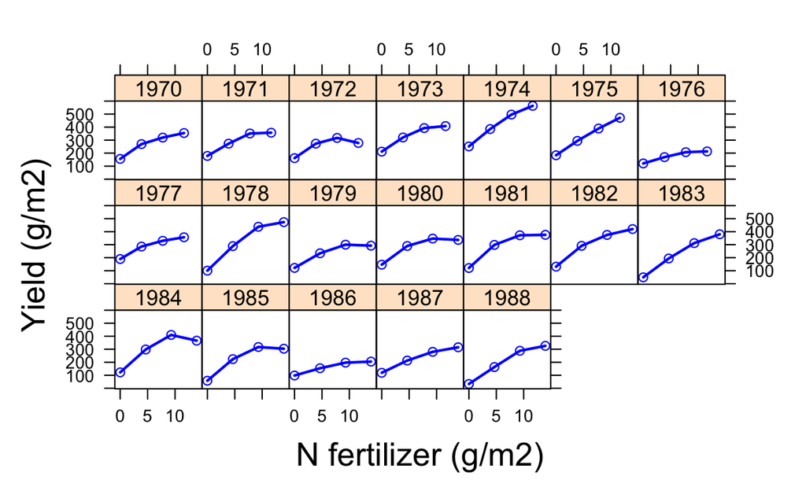

```r
xyplot(yield ~ NF | factor(year),
  data = byield,
  as.table = TRUE, type = "o", lwd = 2, col = "blue",
  xlab = list("N fertilizer (g/m2)", cex = 1.5),
  ylab = list("Yield (g/m2)", cex = 1.5)
)
```

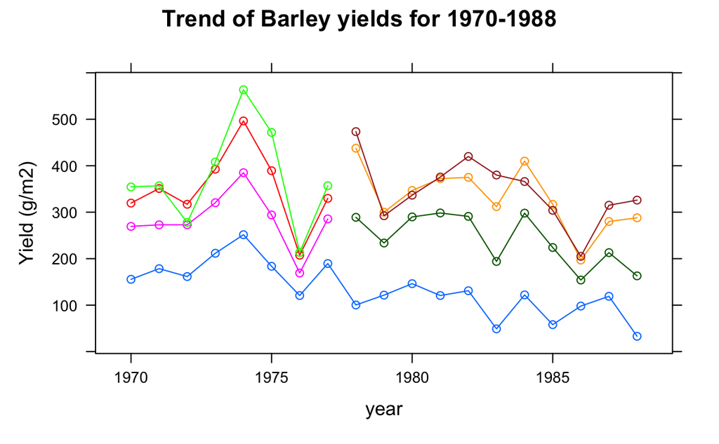

```r
xyplot(yield ~ year,
  data = byield, group = factor(NF), type = "o",
  ylab = "Yield (g/m2)",
  main = "Trend of Barley yields for 1970-1988"
)
```

Defining the structure of the data

```r
byieldG <- groupedData(yield ~ NF | year, data = byield)
```

Graphic tools provided by nlme

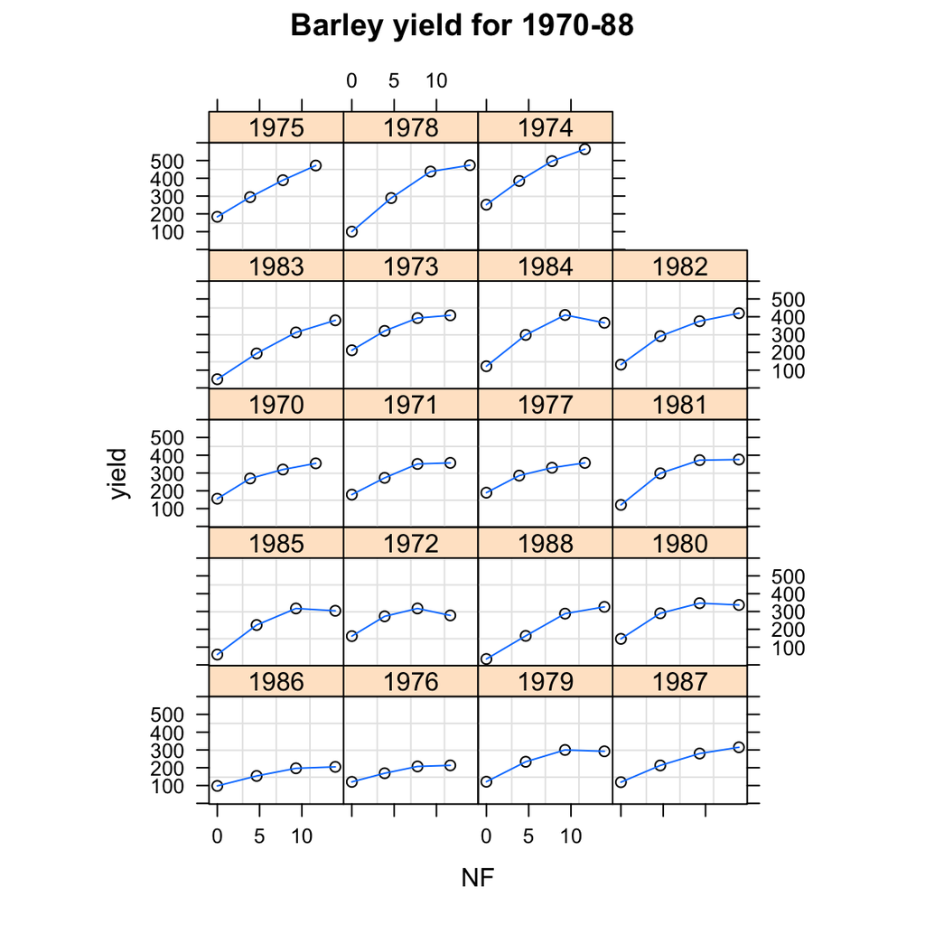

```r
plot(byieldG, col = "black", main = "Barley yield for 1970-88", aspect = 0.8)
```

We can first try to fit an asymptotic model to all the data.

```r
fit.nls <- nls(yield ~ SSasymp(NF, th1, th2, lrc), data = byieldG)
summary(fit.nls)
```

```
Formula: yield ~ SSasymp(NF, th1, th2, lrc)

Parameters:
    Estimate Std. Error t value Pr(>|t|)
th1 381.0394    33.2710  11.453  < 2e-16 ***
th2 133.4740    16.2524   8.213 5.61e-12 ***
lrc  -1.6961     0.3475  -4.881 6.03e-06 ***
---
Signif. codes:  0 ‘***’ 0.001 ‘**’ 0.01 ‘*’ 0.05 ‘.’ 0.1 ‘ ’ 1

Residual standard error: 71.17 on 73 degrees of freedom

Number of iterations to convergence: 4
Achieved convergence tolerance: 1.67e-06
```

Confidence intervals from MASS

```r
confint(fit.nls)
```

```
          2.5%     97.5%
th1 334.631179 507.13096
th2 101.191698 165.65177
lrc  -2.554985  -1.07905
```

Residuals by year. We are not capturing the structure of the data

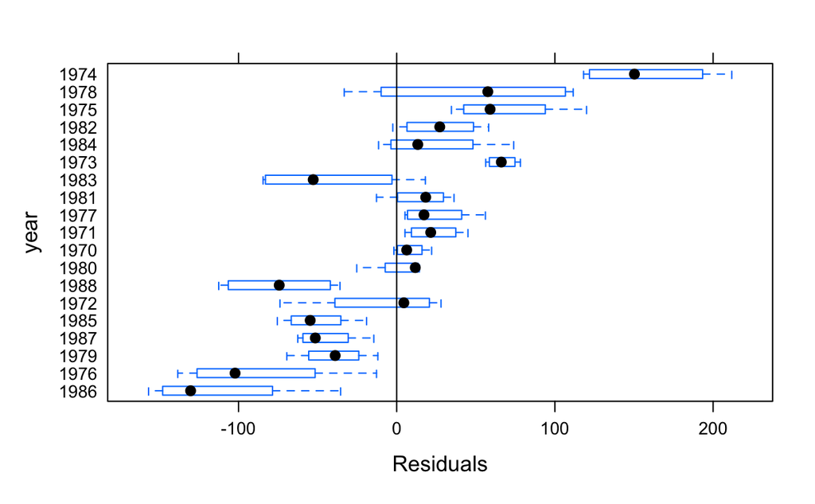

```r
plot(fit.nls, year ~ resid(.), abline = 0)
```

```r
NFs <- data.frame(NF = seq(0, 14, 0.5))
byield.pred <- predict(fit.nls, newdata = NFs)
```

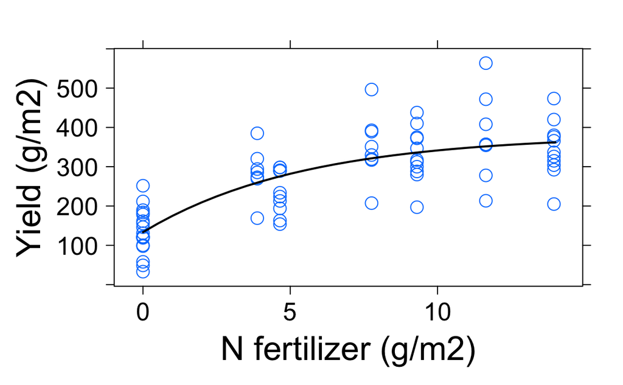

```r
xyplot(yield ~ NF,
  data = byield,
  xlab = list("N fertilizer (g/m2)", cex = 2),
  ylab = list("Yield (g/m2)", cex = 2),
  scales = list(x = list(cex = 1.5), y = list(cex = 1.5)),
  panel = function(x, y, ...) {
    panel.xyplot(x, y, cex = 1.5, pch = 21, ...)
    panel.xyplot(NFs$NF, byield.pred, type = "l", col = "black", lwd = 2, ...)
  }
)
```

This analysis ignores the structure of the data where years are poorly modeled if we are willing to model years as random effects we could accommodate this better. Here we are also ignoring the unbalanced NF

Fitting one function for each year

```r
fit.lis <- nlsList(yield ~ SSasymp(NF, th1, th2, lrc), data = byieldG)
fit.lis
```

```
Call:
  Model: yield ~ SSasymp(NF, th1, th2, lrc) | year
   Data: byieldG

Coefficients:
```

|  | th1 | th2 | lrc |
| --- | --- | --- | --- |
| 1986 | 227.9333 | 97.12993 | -2.0020382 |
| 1976 | 233.1915 | 119.87161 | -1.8109184 |
| 1979 | 310.1746 | 120.40580 | -1.5250256 |
| 1987 | 385.6397 | 118.45790 | -2.3358307 |
| 1985 | 327.8137 | 56.49109 | -1.4740947 |
| 1972 | 296.4495 | 161.16618 | -0.6635742 |
| 1988 | 450.7986 | 29.86366 | -2.3914111 |
| 1980 | 348.5541 | 145.62557 | -1.2534543 |
| 1970 | 382.6852 | 156.06163 | -1.7535471 |
| 1971 | 393.6049 | 176.59383 | -1.7613890 |

[output cut: 9 more lines]

```
Degrees of freedom: 76 total; 19 residual
Residual standard error: 18.63698
```

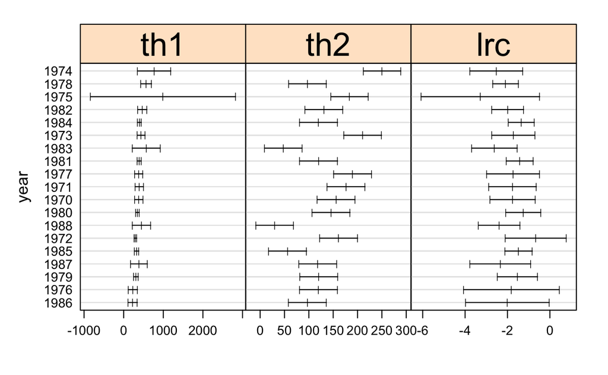

```r
plot(
  intervals(fit.lis),
  layout = c(3, 1),
  lcol = "black",
  par.strip.text = list(cex = 2),
  col = "black"
)
```

This first graph suggest that we do need random effects for theta 1 and theta 2 but the random effect for lrc might not be needed

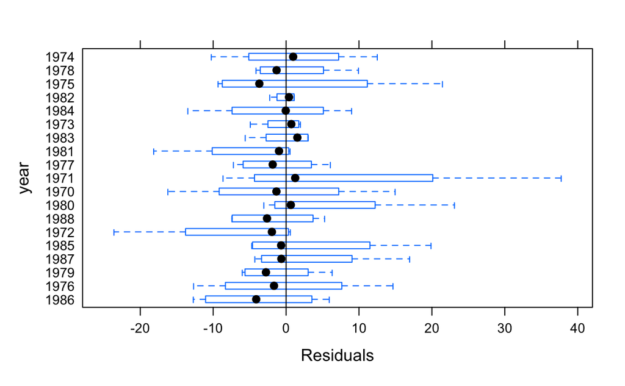

```r
plot(fit.lis, year ~ resid(.), abline = 0)
```

This plot shows a much better spread for the residuals than the single non-linear equation fitted to all of the data. This is naturally expected.

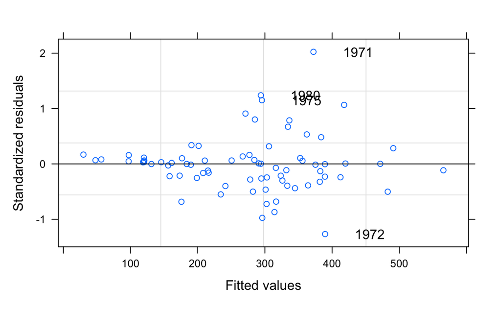

```r
plot(fit.lis, id = 0.25, adj = -1)
```

The standardized residuals allows us to see the outliers for individual years. Notice that they are within 2.

The problem with this approach is that we are using (19 x 3 = 57) 57 parameters to model these data and we are not taking advantage of the similarity among curves additionally we don’t have an estimate of how much these parameters vary among years.

Finally fitting a non-linear mixed model.

```r
fit.nlme <- nlme(fit.lis)
fit.nlme
```

```
Nonlinear mixed-effects model fit by maximum likelihood
  Model: yield ~ SSasymp(NF, th1, th2, lrc)
  Data: byieldG
  Log-likelihood: -385.9793
  Fixed: list(th1 ~ 1, th2 ~ 1, lrc ~ 1)
      th1       th2       lrc
390.15366 131.75232  -1.66514

Random effects:
 Formula: list(th1 ~ 1, th2 ~ 1, lrc ~ 1)
 Level: year
 Structure: General positive-definite, Log-Cholesky parametrization
         StdDev      Corr
th1      106.6362562 th1    th2
th2       51.0293403  0.354
lrc        0.3169541 -0.799  0.214
Residual  18.7954501

Number of Observations: 76
Number of Groups: 19
```

```r
intervals(fit.nlme)
```

```
Approximate 95% confidence intervals

 Fixed effects:
         lower      est.      upper
th1 337.331328 390.15366 442.975999
th2 106.772010 131.75232 156.732632
lrc  -1.890842  -1.66514  -1.439437

 Random Effects:
  Level: year
                  lower        est.       upper
sd(th1)      69.3038261 106.6362562 164.0788365
sd(th2)      35.5029275  51.0293403  73.3458831
sd(lrc)       0.1235733   0.3169541   0.8129578
cor(th1,th2) -0.1775315   0.3541783   0.7258308
cor(th1,lrc) -0.9574670  -0.7989576  -0.2700187
cor(th2,lrc) -0.5399194   0.2143151   0.7776595

 Within-group standard error:
   lower     est.    upper
13.80985 18.79545 25.58095
```

Comparing these estimates to the simple non-linear function

```r
## Simple
coef(fit.nls)
```

```
       th1        th2        lrc
381.039363 133.474007  -1.696127
```

```r
## nlme
fit.nlme$coefficients$fixed
```

```
      th1       th2       lrc
390.15366 131.75232  -1.66514
```

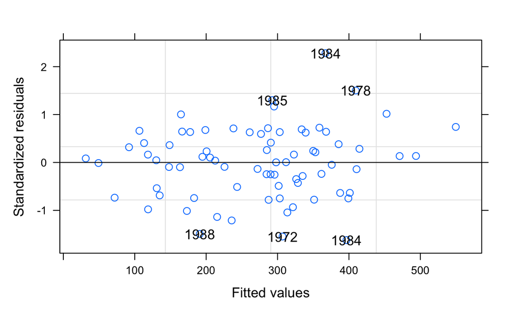

```r
## Model checking
plot(fit.nlme, id = 0.2)
```

These residuals look even better than the ones from the individual fits

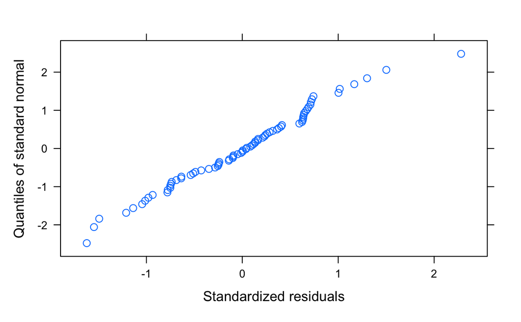

```r
qqnorm(fit.nlme)
```

Normality is not a problem here

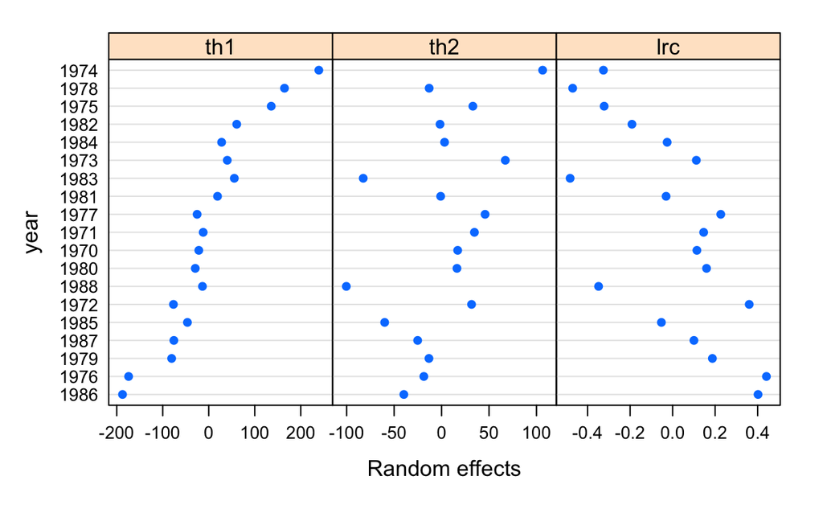

```r
plot(ranef(fit.nlme, augFrame = T), layout = c(3, 1))
```

This is an interesting plot because it shows the variability in the random effects by year. It would be interesting to add a plot where the years are sorted to detect a possible trend.

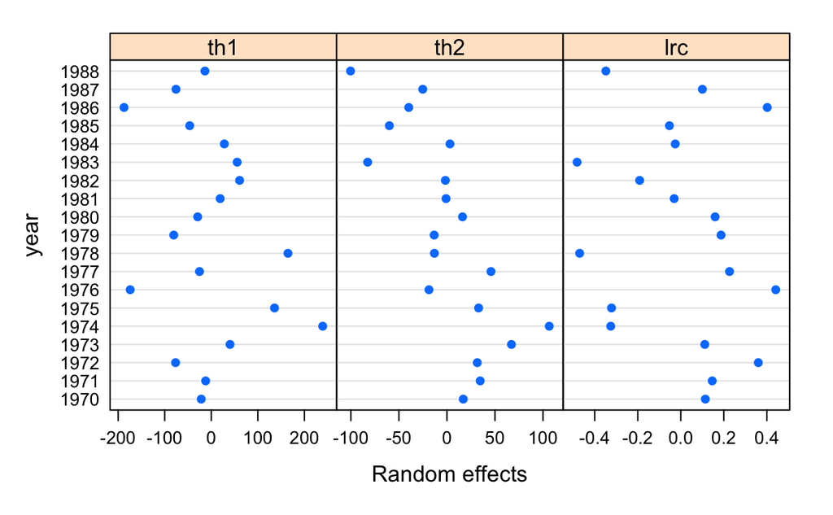

```r
ranef.fnlme <- ranef(fit.nlme, augFrame = TRUE)
dd <- data.frame(ind = 1:19, rn = row.names(ranef.fnlme))
dd.o <- dd[order(dd$rn), ]$ind
ranef.fnlme2 <- ranef.fnlme[dd.o, ]

plot(ranef.fnlme2, layout = c(3, 1))
```

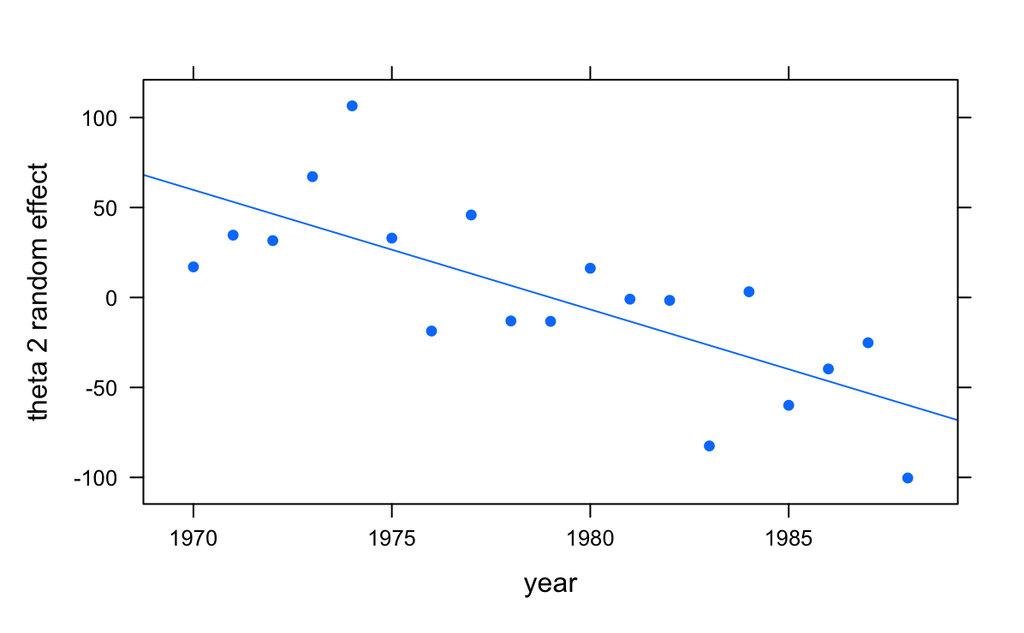

```r
xyplot(ranef.fnlme2$th2 ~ 1970:1988,
  type = c("p", "r"),
  xlab = "year", ylab = "theta 2 random effect",
  pch = 16
)
```

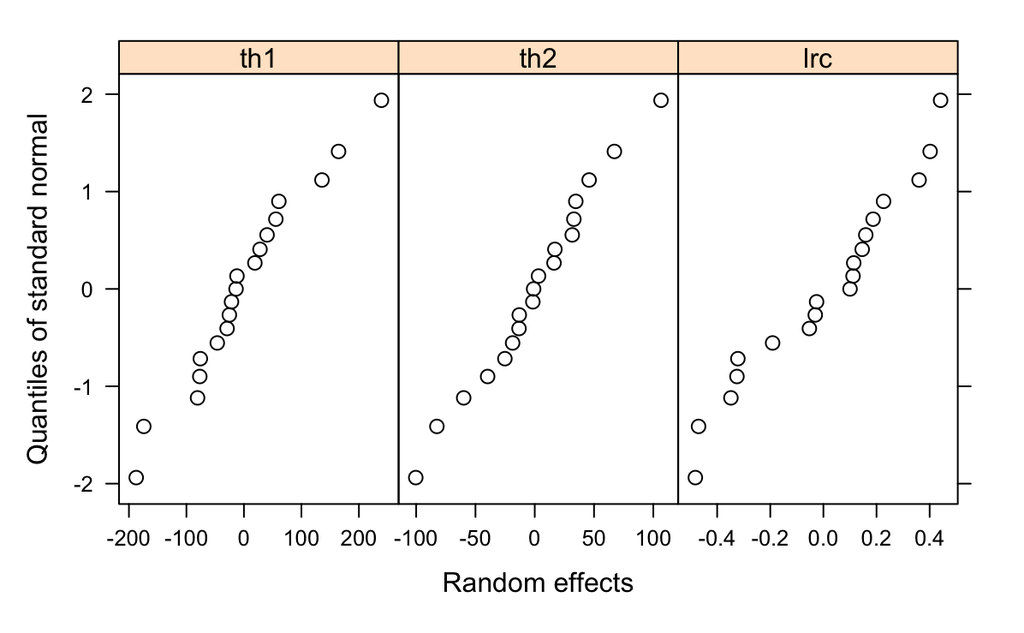

```r
qqnorm(fit.nlme, ~ ranef(.), col = "black")
```

Normality of the random effects for each parameter

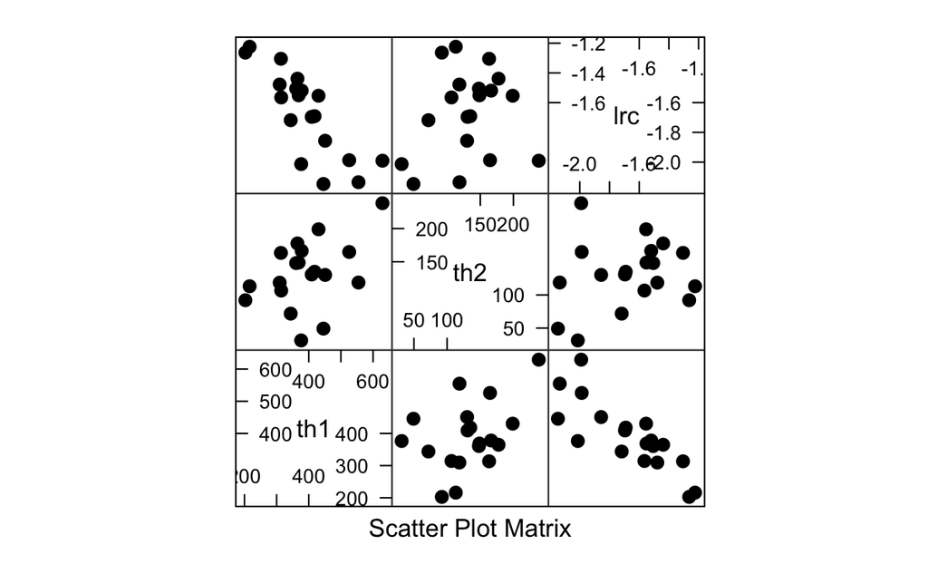

```r
pairs(fit.nlme, pch = 19, col = "black")
```

Visual assesment of the correlation for the random effects

```r
intervals(fit.nlme, which = "var-cov")
```

```
Approximate 95% confidence intervals

 Random Effects:
  Level: year
                  lower        est.       upper
sd(th1)      69.3038261 106.6362562 164.0788365
sd(th2)      35.5029275  51.0293403  73.3458831
sd(lrc)       0.1235733   0.3169541   0.8129578
cor(th1,th2) -0.1775315   0.3541783   0.7258308
cor(th1,lrc) -0.9574670  -0.7989576  -0.2700187
cor(th2,lrc) -0.5399194   0.2143151   0.7776595

 Within-group standard error:
   lower     est.    upper
13.80985 18.79545 25.58095
```

Need to add an interpretation of the negative correlation between the random effects.

Trying to simplify the variance covariance matrix of the random effects.

```r
fit2.nlme <- update(fit.nlme, random = pdBlocked(list(th1 + lrc ~ 1, th2 ~ 1)))
fit2.nlme
```

```
Nonlinear mixed-effects model fit by maximum likelihood
  Model: yield ~ SSasymp(NF, th1, th2, lrc)
  Data: byieldG
  Log-likelihood: -389.826
  Fixed: list(th1 ~ 1, th2 ~ 1, lrc ~ 1)
       th1        th2        lrc
395.108608 132.108270  -1.739045

Random effects:
 Composite Structure: Blocked

 Block 1: th1, lrc
 Formula: list(th1 ~ 1, lrc ~ 1)
 Level: year
 Structure: General positive-definite
    StdDev      Corr
th1 108.1469325 th1
lrc   0.3298673 -0.704

 Block 2: th2
 Formula: th2 ~ 1 | year
            th2 Residual
StdDev: 53.2016 18.11283

Number of Observations: 76
Number of Groups: 19
```

```r
fit3.nlme <- update(fit.nlme, random = pdBlocked(list(th1 ~ 1, lrc ~ 1, th2 ~ 1)))
fit3.nlme
```

```
Nonlinear mixed-effects model fit by maximum likelihood
  Model: yield ~ SSasymp(NF, th1, th2, lrc)
  Data: byieldG
  Log-likelihood: -391.2547
  Fixed: list(th1 ~ 1, th2 ~ 1, lrc ~ 1)
       th1        th2        lrc
395.068909 132.883853  -1.824138

Random effects:
 Composite Structure: Blocked

 Block 1: th1
 Formula: th1 ~ 1 | year
             th1
StdDev: 89.07013

 Block 2: lrc
 Formula: lrc ~ 1 | year
              lrc
StdDev: 0.1547474

 Block 3: th2
 Formula: th2 ~ 1 | year
             th2 Residual
StdDev: 52.17255 20.35377

Number of Observations: 76
Number of Groups: 19
```

```r
fit4.nlme <- update(fit.nlme, random = pdDiag(list(th1 ~ 1, lrc ~ 1, th2 ~ 1)))
fit4.nlme
```

```
Nonlinear mixed-effects model fit by maximum likelihood
  Model: yield ~ SSasymp(NF, th1, th2, lrc)
  Data: byieldG
  Log-likelihood: -391.2564
  Fixed: list(th1 ~ 1, th2 ~ 1, lrc ~ 1)
       th1        th2        lrc
395.041206 132.877570  -1.823913

Random effects:
 Formula: list(th1 ~ 1, lrc ~ 1, th2 ~ 1)
 Level: year
 Structure: Diagonal
             th1       lrc     th2 Residual
StdDev: 89.08636 0.1553269 52.1691 20.34774

Number of Observations: 76
Number of Groups: 19
```

```r
intervals(fit2.nlme, which = "var-cov")
```

```
Approximate 95% confidence intervals

 Random Effects:
  Level: year
                  lower        est.        upper
sd(th1)      70.4534165 108.1469325 166.00698167
sd(lrc)       0.1398406   0.3298673   0.77811730
cor(th1,lrc) -0.9328369  -0.7036447  -0.06904601
sd(th2)      37.3676786  53.2015996  75.74487636

 Within-group standard error:
   lower     est.    upper
13.47744 18.11283 24.34249
```

```r
anova(fit.nlme, fit2.nlme, fit3.nlme, fit4.nlme)
```

|  | Model | df | AIC | BIC | logLik | Test | L.Ratio | p-value |
| --- | --- | --- | --- | --- | --- | --- | --- | --- |
| fit.nlme | 1 | 10 | 791.9586 | 815.2660 | -385.9793 |  |  |  |
| fit2.nlme | 2 | 8 | 795.6519 | 814.2978 | -389.8260 | 1 vs 2 | 7.693291 | 0.0214 |
| fit3.nlme | 3 | 7 | 796.5093 | 812.8245 | -391.2547 | 2 vs 3 | 2.857409 | 0.0910 |
| fit4.nlme | 4 | 7 | 796.5127 | 812.8279 | -391.2564 |  |  |  |

The more general variance covariance matrix is better

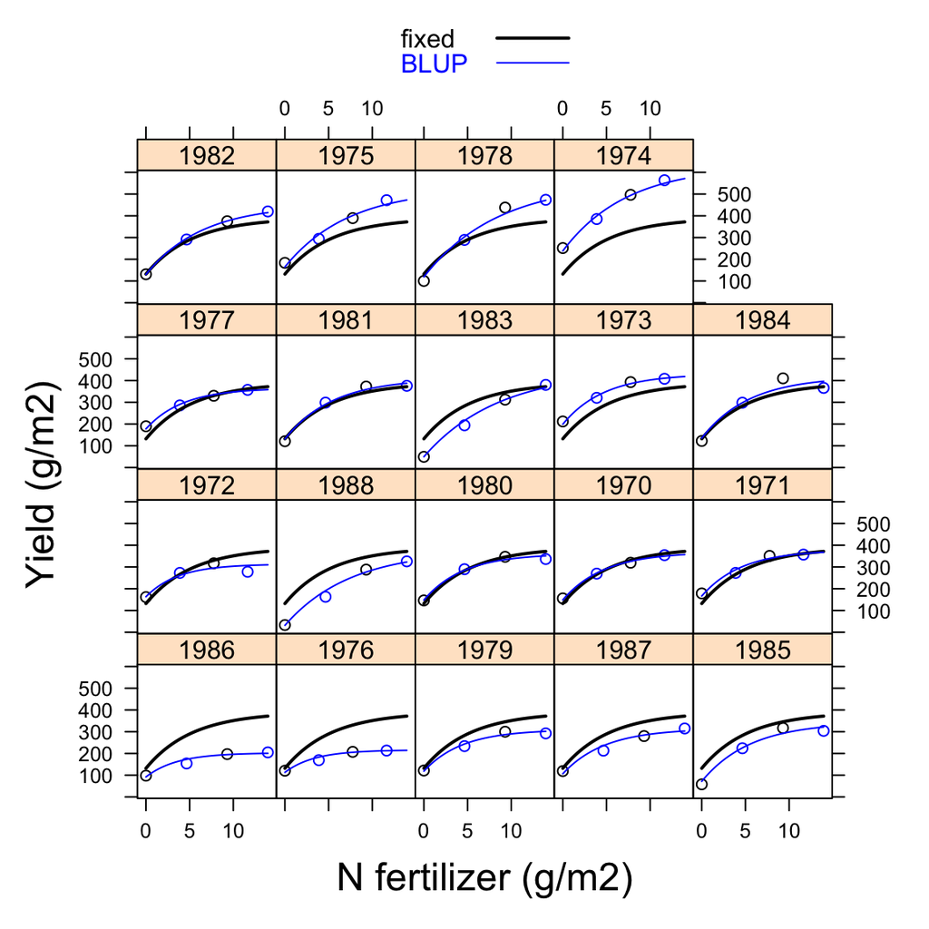

```r
plot(augPred(fit.nlme, level = 0:1),
  lwd = c(2, 1), col = c("black", "blue"),
  ylab = list("Yield (g/m2)", cex = 1.5),
  xlab = list("N fertilizer (g/m2)", cex = 1.5),
  key = list(
    text = list(c("fixed", "BLUP")), lines = TRUE, pch = 21, lty = 1,
    lwd = c(2, 1), col = c("black", "blue")
  )
)
```

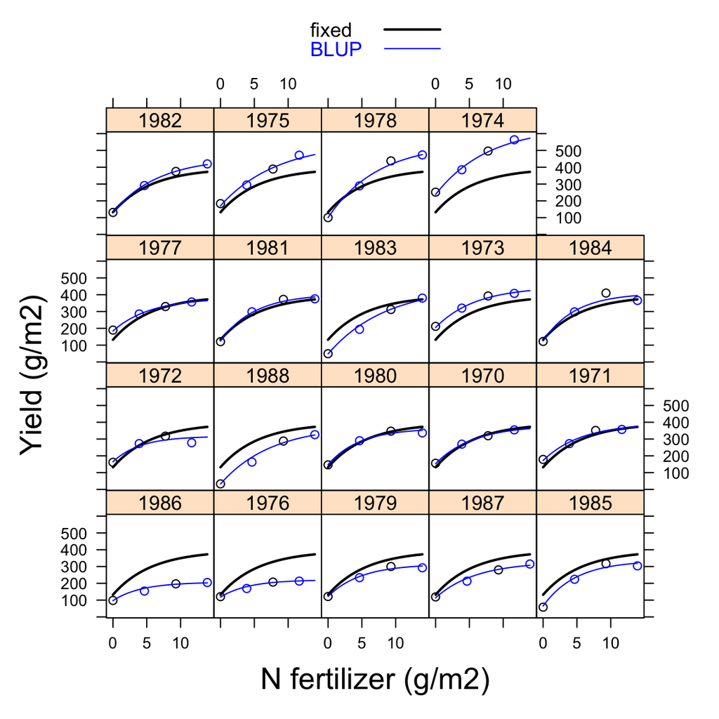

```r
plot(augPred(fit2.nlme, level = 0:1),
  lwd = c(2, 1), col = c("black", "blue"),
  ylab = list("Yield (g/m2)", cex = 1.5),
  xlab = list("N fertilizer (g/m2)", cex = 1.5),
  key = list(
    text = list(c("fixed", "BLUP")), lines = TRUE, pch = 21, lty = 1,
    lwd = c(2, 1), col = c("black", "blue")
  )
)
```

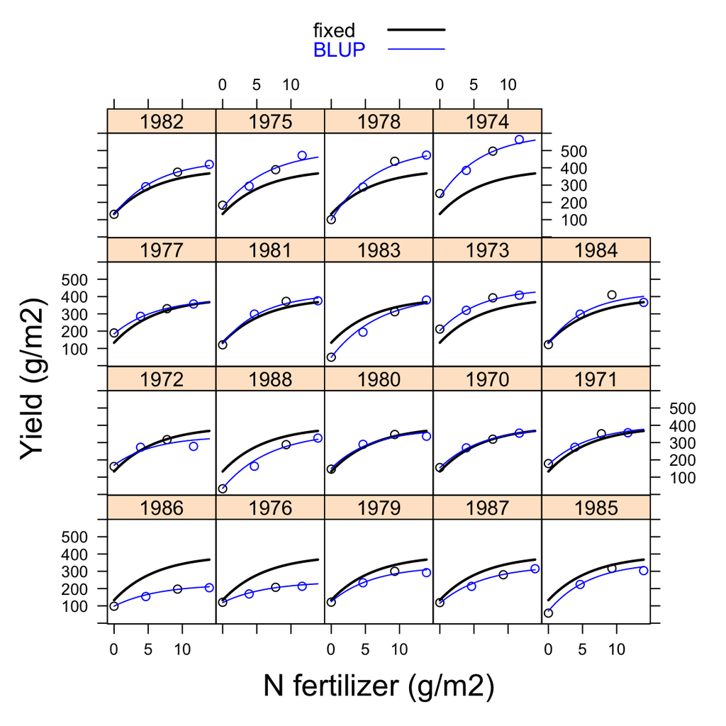

```r
plot(augPred(fit3.nlme, level = 0:1),
  lwd = c(2, 1), col = c("black", "blue"),
  ylab = list("Yield (g/m2)", cex = 1.5),
  xlab = list("N fertilizer (g/m2)", cex = 1.5),
  key = list(
    text = list(c("fixed", "BLUP")), lines = TRUE, pch = 21, lty = 1,
    lwd = c(2, 1), col = c("black", "blue")
  )
)
```

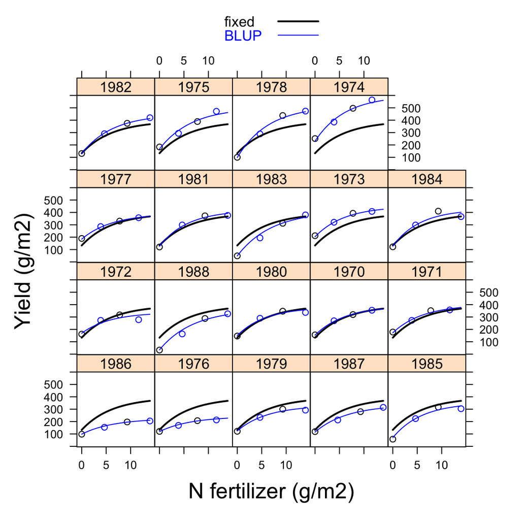

```r
plot(augPred(fit4.nlme, level = 0:1),
  lwd = c(2, 1), col = c("black", "blue"),
  ylab = list("Yield (g/m2)", cex = 1.5),
  xlab = list("N fertilizer (g/m2)", cex = 1.5),
  key = list(
    text = list(c("fixed", "BLUP")), lines = TRUE, pch = 21, lty = 1,
    lwd = c(2, 1), col = c("black", "blue")
  )
)
```

```r
# growth rate in a better scale
intervals(fit.nlme, which = "fixed")
```

```
Approximate 95% confidence intervals

 Fixed effects:
         lower      est.      upper
th1 337.331328 390.15366 442.975999
th2 106.772010 131.75232 156.732632
lrc  -1.890842  -1.66514  -1.439437
```

```r
lrc <- c(-1.890842, -1.66514, -1.439437)
log(2) / exp(lrc)
```

```
[1] 4.592062 3.664262 2.923917
```